# Binary Classification Model for Heart Disease Study Using R Take 5

David Lowe

May 31, 2019

Template Credit: Adapted from a template made available by Dr. Jason Brownlee of Machine Learning Mastery. [http://machinelearningmastery.com/]

SUMMARY: The purpose of this project is to construct a prediction model using various machine learning algorithms and to document the end-to-end steps using a template. The Heart Disease dataset is a binary classification situation where we are trying to predict one of the two possible outcomes.

INTRODUCTION: The original database contains 76 attributes, but all published experiments refer to using a subset of 14 of them. In particular, the Cleveland database is the only one that has been used by machine learning researchers to this date. The “num” field refers to the presence of heart disease in the patient. It is integer valued from 0 (no presence) to 4. Experiments with the Cleveland database have concentrated on simply attempting to distinguish presence (values 1,2,3,4) from absence (value 0).

In iteration Take1, we examined the Cleveland dataset and created a machine learning model to fit the data.

In iteration Take2, we examined the Hungarian dataset and created a machine learning model to fit the data.

In iteration Take3, we examined the Switzerland dataset and created a machine learning model to fit the data.

In iteration Take3, we examined the Long Beach VA dataset and created a machine learning model to fit the data.

In this iteration, we will combine all four datasets and create a machine learning model to fit the data.

CONCLUSION: For the combined dataset, the Gradient Boosting algorithm achieved the best overall results using the training and testing datasets. For this dataset, Gradient Boosting could be considered for further modeling or production use.

Dataset Used: Heart Disease Data Set

Dataset ML Model: Binary classification with numerical and categorical attributes

Dataset Reference: https://archive.ics.uci.edu/ml/datasets/Heart+Disease

One potential source of performance benchmark: https://www.kaggle.com/ronitf/heart-disease-uci

The project aims to touch on the following areas:

1. Document a predictive modeling problem end-to-end.
2. Explore data cleaning and transformation options
3. Explore non-ensemble and ensemble algorithms for baseline model performance
4. Explore algorithm tuning techniques for improving model performance

Any predictive modeling machine learning project genrally can be broken down into about six major tasks:

1. Prepare Problem
2. Summarize Data
3. Prepare Data
4. Model and Evaluate Algorithms
5. Improve Accuracy or Results
6. Finalize Model and Present Results

## 1. Prepare Problem

### 1.a) Load libraries

```r
startTimeScript <- proc.time()
library(caret)
```

```r
library(corrplot)
library(mailR)
library(stringr)
library(MLmetrics)
library(DMwR)
library(ROCR)
library(mlbench)
library(Hmisc)
# Create one random seed number for reproducible results
seedNum <- 888
set.seed(seedNum)
```

### 1.b) Set up the email notification function

```r
email_notify <- function(msg=""){
  sender <- Sys.getenv("MAIL_SENDER")
  receiver <- Sys.getenv("MAIL_RECEIVER")
  gateway <- Sys.getenv("SMTP_GATEWAY")
  smtpuser <- Sys.getenv("SMTP_USERNAME")
  password <- Sys.getenv("SMTP_PASSWORD")
  sbj_line <- "Notification from R Binary Classification Script"
  send.mail(
    from = sender,
    to = receiver,
    subject= sbj_line,
    body = msg,
    smtp = list(host.name = gateway, port = 587, user.name = smtpuser, passwd = password, ssl = TRUE),
    authenticate = TRUE,
    send = TRUE)
}
```

```r
email_notify(paste("Library and Data Loading has begun!",date()))
```

```
## [1] "Java-Object{org.apache.commons.mail.SimpleEmail@35851384}"
```

### 1.c) Load dataset

```r
# Slicing up the document path to get the final destination file name
dataset_path <- 'https://archive.ics.uci.edu/ml/machine-learning-databases/heart-disease/processed.cleveland.data'
doc_path_list <- str_split(dataset_path, "/")
dest_file <- doc_path_list[[1]][length(doc_path_list[[1]])]

if (!file.exists(dest_file)) {
  # Download the document from the website
  cat("Downloading", dataset_path, "as", dest_file, "\n")
  download.file(dataset_path, dest_file, mode = "wb")
  cat(dest_file, "downloaded!\n")
#  unzip(dest_file)
#  cat(dest_file, "unpacked!\n")
} else {
  cat(dest_file, 'already exists. Will not download again!')
}
```

```
## processed.cleveland.data already exists. Will not download again!
```

```r
inputFile <- dest_file
colNames <- c('age','sex','cp','trestbps','chol','fbs','restecg','thalach','exang','oldpeak','slope','ca','thal','num')
xy_cleveland <- read.csv(inputFile, sep = ',', header = FALSE, col.names = colNames, na.strings = "?")
```

```r
# Slicing up the document path to get the final destination file name
dataset_path <- 'https://archive.ics.uci.edu/ml/machine-learning-databases/heart-disease/processed.hungarian.data'
doc_path_list <- str_split(dataset_path, "/")
dest_file <- doc_path_list[[1]][length(doc_path_list[[1]])]

if (!file.exists(dest_file)) {
  # Download the document from the website
  cat("Downloading", dataset_path, "as", dest_file, "\n")
  download.file(dataset_path, dest_file, mode = "wb")
  cat(dest_file, "downloaded!\n")
#  unzip(dest_file)
#  cat(dest_file, "unpacked!\n")
} else {
  cat(dest_file, 'already exists. Will not download again!')
}
```

```
## processed.hungarian.data already exists. Will not download again!
```

```r
inputFile <- dest_file
colNames <- c('age','sex','cp','trestbps','chol','fbs','restecg','thalach','exang','oldpeak','slope','ca','thal','num')
xy_hungarian <- read.csv(inputFile, sep = ',', header = FALSE, col.names = colNames, na.strings = "?")
```

```r
# Slicing up the document path to get the final destination file name
dataset_path <- 'https://archive.ics.uci.edu/ml/machine-learning-databases/heart-disease/processed.switzerland.data'
doc_path_list <- str_split(dataset_path, "/")
dest_file <- doc_path_list[[1]][length(doc_path_list[[1]])]

if (!file.exists(dest_file)) {
  # Download the document from the website
  cat("Downloading", dataset_path, "as", dest_file, "\n")
  download.file(dataset_path, dest_file, mode = "wb")
  cat(dest_file, "downloaded!\n")
#  unzip(dest_file)
#  cat(dest_file, "unpacked!\n")
} else {
  cat(dest_file, 'already exists. Will not download again!')
}
```

```
## processed.switzerland.data already exists. Will not download again!
```

```r
inputFile <- dest_file
colNames <- c('age','sex','cp','trestbps','chol','fbs','restecg','thalach','exang','oldpeak','slope','ca','thal','num')
xy_switzerland <- read.csv(inputFile, sep = ',', header = FALSE, col.names = colNames, na.strings = "?")
```

```r
# Slicing up the document path to get the final destination file name
dataset_path <- 'https://archive.ics.uci.edu/ml/machine-learning-databases/heart-disease/processed.va.data'
doc_path_list <- str_split(dataset_path, "/")
dest_file <- doc_path_list[[1]][length(doc_path_list[[1]])]

if (!file.exists(dest_file)) {
  # Download the document from the website
  cat("Downloading", dataset_path, "as", dest_file, "\n")
  download.file(dataset_path, dest_file, mode = "wb")
  cat(dest_file, "downloaded!\n")
#  unzip(dest_file)
#  cat(dest_file, "unpacked!\n")
} else {
  cat(dest_file, 'already exists. Will not download again!')
}
```

```
## processed.va.data already exists. Will not download again!
```

```r
inputFile <- dest_file
colNames <- c('age','sex','cp','trestbps','chol','fbs','restecg','thalach','exang','oldpeak','slope','ca','thal','num')
xy_longbeach <- read.csv(inputFile, sep = ',', header = FALSE, col.names = colNames, na.strings = "?")
```

```r
xy_original <- rbind(xy_cleveland, xy_hungarian, xy_switzerland, xy_longbeach)
```

```r
# Take a peek at the dataframe after the import
head(xy_original)
```

```
##   age sex cp trestbps chol fbs restecg thalach exang oldpeak slope ca thal
## 1  63   1  1      145  233   1       2     150     0     2.3     3  0    6
## 2  67   1  4      160  286   0       2     108     1     1.5     2  3    3
## 3  67   1  4      120  229   0       2     129     1     2.6     2  2    7
## 4  37   1  3      130  250   0       0     187     0     3.5     3  0    3
## 5  41   0  2      130  204   0       2     172     0     1.4     1  0    3
## 6  56   1  2      120  236   0       0     178     0     0.8     1  0    3
##   num
## 1   0
## 2   2
## 3   1
## 4   0
## 5   0
## 6   0
```

```r
sapply(xy_original, class)
```

```
##       age       sex        cp  trestbps      chol       fbs   restecg
## "numeric" "numeric" "numeric" "numeric" "numeric" "numeric" "numeric"
##   thalach     exang   oldpeak     slope        ca      thal       num
## "numeric" "numeric" "numeric" "numeric" "numeric" "numeric" "integer"
```

```r
sapply(xy_original, function(x) sum(is.na(x)))
```

```
##      age      sex       cp trestbps     chol      fbs  restecg  thalach
##        0        0        0       59       30       90        2       55
##    exang  oldpeak    slope       ca     thal      num
##       55       62      309      611      486        0
```

### 1.d) Data Cleaning

```r
# Due to the large number of missing data in these columns, we will drop them from the dataset
xy_original$ca <- NULL
xy_original$thal <- NULL

# Perform some immediate cleaning tasks to get data into the right formats and types
xy_original$age <- as.integer(xy_original$age)
xy_original$sex <- as.integer(xy_original$sex)
xy_original$sex <- as.factor(xy_original$sex)
xy_original$cp <- as.integer(xy_original$cp)
xy_original$cp <- as.factor(xy_original$cp)

# impute the missing values with values appropriate for the attributes
xy_original$trestbps <- with(xy_original, impute(trestbps, median))
xy_original$trestbps <- as.integer(xy_original$trestbps)

chol_median <- median(xy_original$chol, na.rm = TRUE)
xy_original$chol[xy_original$chol==0] <- chol_median
xy_original$chol <- with(xy_original, impute(chol, chol_median))
xy_original$chol <- as.integer(xy_original$chol)

xy_original$fbs <- with(xy_original, impute(fbs, 0))
xy_original$fbs <- as.integer(xy_original$fbs)
xy_original$fbs <- as.factor(xy_original$fbs)

xy_original$restecg <- with(xy_original, impute(restecg, 0))
xy_original$restecg <- as.integer(xy_original$restecg)
xy_original$restecg <- as.factor(xy_original$restecg)

xy_original$thalach <- with(xy_original, impute(thalach, median))
xy_original$thalach <- as.integer(xy_original$thalach)

xy_original$exang <- with(xy_original, impute(exang, 0))
xy_original$exang <- as.integer(xy_original$exang)
xy_original$exang <- as.factor(xy_original$exang)

xy_original$oldpeak <- with(xy_original, impute(oldpeak, median))

xy_original$slope <- with(xy_original, impute(slope, 0))
xy_original$slope <- as.integer(xy_original$slope)
xy_original$slope <- as.factor(xy_original$slope)
```

```r
# Transform the num codes to their corresponding categories
reClassNum <- function(num_code) {
  num_category <-
    if (num_code >= 1) 1 else 0
  return(num_category)
}

xy_original$num <- sapply(xy_original$num, reClassNum)
xy_original$num <- as.factor(xy_original$num)
```

```r
# Take a peek at the dataframe after the cleaning
head(xy_original)
```

```
##   age sex cp trestbps chol fbs restecg thalach exang oldpeak slope num
## 1  63   1  1      145  233   1       2     150     0     2.3     3   0
## 2  67   1  4      160  286   0       2     108     1     1.5     2   1
## 3  67   1  4      120  229   0       2     129     1     2.6     2   1
## 4  37   1  3      130  250   0       0     187     0     3.5     3   0
## 5  41   0  2      130  204   0       2     172     0     1.4     1   0
## 6  56   1  2      120  236   0       0     178     0     0.8     1   0
```

```r
sapply(xy_original, class)
```

```
##       age       sex        cp  trestbps      chol       fbs   restecg
## "integer"  "factor"  "factor" "integer" "integer"  "factor"  "factor"
##   thalach     exang   oldpeak     slope       num
## "integer"  "factor"  "impute"  "factor"  "factor"
```

```r
sapply(xy_original, function(x) sum(is.na(x)))
```

```
##      age      sex       cp trestbps     chol      fbs  restecg  thalach
##        0        0        0        0        0        0        0        0
##    exang  oldpeak    slope      num
##        0        0        0        0
```

### 1.e) Splitting Data into Training and Testing Sets

```r
# Use variable totCol to hold the number of columns in the dataframe
totCol <- ncol(xy_original)

# Set up variable totAttr for the total number of attribute columns
totAttr <- totCol-1
```

```r
# targetCol variable indicates the column location of the target/class variable
# If the first column, set targetCol to 1. If the last column, set targetCol to totCol
# if (targetCol <> 1) and (targetCol <> totCol), be aware when slicing up the dataframes for visualization!
targetCol <- totCol

# Standardize the class column to the name of targetVar if applicable
colnames(xy_original)[targetCol] <- "targetVar"
#xy_original$targetVar <- relevel(xy_original$targetVar,"pos")
```

```r
# We create training datasets (xy_train, x_train, y_train) for various visualization and cleaning/transformation operations.
# We create testing datasets (xy_test, y_test) for various visualization and cleaning/transformation operations.
set.seed(seedNum)

# Create a list of the rows in the original dataset we can use for training
# Use 70% of the data to train the models and the remaining for testing/validation
training_index <- createDataPartition(xy_original$targetVar, p=0.70, list=FALSE)
xy_train <- xy_original[training_index,]
xy_test <- xy_original[-training_index,]

if (targetCol==1) {
x_train <- xy_train[,(targetCol+1):totCol]
y_train <- xy_train[,targetCol]
y_test <- xy_test[,targetCol]
} else {
x_train <- xy_train[,1:(totAttr)]
y_train <- xy_train[,totCol]
y_test <- xy_test[,totCol]
}
```

### 1.f) Set up the key parameters to be used in the script

```r
# Set up the number of row and columns for visualization display. dispRow * dispCol should be >= totAttr
dispCol <- 4
if (totAttr%%dispCol == 0) {
dispRow <- totAttr%/%dispCol
} else {
dispRow <- (totAttr%/%dispCol) + 1
}
cat("Will attempt to create graphics grid (col x row): ", dispCol, ' by ', dispRow)
```

```
## Will attempt to create graphics grid (col x row):  4  by  3
```

```r
# Run algorithms using 10-fold cross validation
control <- trainControl(method="repeatedcv", number=10, repeats=3)
metricTarget <- "Accuracy"
```

```r
email_notify(paste("Library and Data Loading completed!",date()))
```

```
## [1] "Java-Object{org.apache.commons.mail.SimpleEmail@3c5a99da}"
```

## 2. Summarize Data

To gain a better understanding of the data that we have on-hand, we will leverage a number of descriptive statistics and data visualization techniques. The plan is to use the results to consider new questions, review assumptions, and validate hypotheses that we can investigate later with specialized models.

```r
email_notify(paste("Data Summarization and Visualization has begun!",date()))
```

```
## [1] "Java-Object{org.apache.commons.mail.SimpleEmail@7e0babb1}"
```

### 2.a) Descriptive statistics

#### 2.a.i) Peek at the data itself.

```r
head(xy_train)
```

```
##    age sex cp trestbps chol fbs restecg thalach exang oldpeak slope
## 2   67   1  4      160  286   0       2     108     1     1.5     2
## 3   67   1  4      120  229   0       2     129     1     2.6     2
## 4   37   1  3      130  250   0       0     187     0     3.5     3
## 8   57   0  4      120  354   0       0     163     1     0.6     1
## 9   63   1  4      130  254   0       2     147     0     1.4     2
## 11  57   1  4      140  192   0       0     148     0     0.4     2
##    targetVar
## 2          1
## 3          1
## 4          0
## 8          0
## 9          1
## 11         0
```

#### 2.a.ii) Dimensions of the dataset.

```r
dim(xy_train)
```

```
## [1] 645  12
```

#### 2.a.iii) Types of the attributes.

```r
sapply(xy_train, class)
```

```
##       age       sex        cp  trestbps      chol       fbs   restecg
## "integer"  "factor"  "factor" "integer" "integer"  "factor"  "factor"
##   thalach     exang   oldpeak     slope targetVar
## "integer"  "factor"  "impute"  "factor"  "factor"
```

#### 2.a.iv) Statistical summary of all attributes.

```r
summary(xy_train)
```

```
##
##  43 values imputed to 0.5
```

```
##       age        sex     cp         trestbps          chol       fbs
##  Min.   :28.00   0:131   1: 29   Min.   : 80.0   Min.   :117.0   0:554
##  1st Qu.:47.00   1:514   2:125   1st Qu.:120.0   1st Qu.:215.0   1: 91
##  Median :54.00           3:142   Median :130.0   Median :223.0
##  Mean   :53.28           4:349   Mean   :131.5   Mean   :240.4
##  3rd Qu.:60.00                   3rd Qu.:140.0   3rd Qu.:265.0
##  Max.   :77.00                   Max.   :200.0   Max.   :603.0
##  restecg    thalach      exang      oldpeak        slope   targetVar
##  0:396   Min.   : 60.0   0:407   Min.   :-2.6000   0:219   0:288
##  1:126   1st Qu.:120.0   1:238   1st Qu.: 0.0000   1:145   1:357
##  2:123   Median :140.0           Median : 0.5000   2:239
##          Mean   :137.4           Mean   : 0.8375   3: 42
##          3rd Qu.:155.0           3rd Qu.: 1.5000
##          Max.   :202.0           Max.   : 5.6000
```

#### 2.a.v) Count missing values.

```r
sapply(xy_train, function(x) sum(is.na(x)))
```

```
##       age       sex        cp  trestbps      chol       fbs   restecg
##         0         0         0         0         0         0         0
##   thalach     exang   oldpeak     slope targetVar
##         0         0         0         0         0
```

#### 2.a.vi) Summarize the levels of the class attribute.

```r
cbind(freq=table(y_train), percentage=prop.table(table(y_train))*100)
```

```
##   freq percentage
## 0  288   44.65116
## 1  357   55.34884
```

### 2.b) Data visualizations

#### 2.b.i) Univariate plots to better understand each attribute.

```r
# Boxplots for each attribute
# par(mfrow=c(dispRow,dispCol))
# for(i in 1:totAttr) {
#   boxplot(x_train[,i], main=names(x_train)[i])
# }
```

```r
# Histograms each attribute
# par(mfrow=c(dispRow,dispCol))
# for(i in 1:totAttr) {
#   hist(x_train[,i], main=names(x_train)[i])
# }
```

```r
# Density plot for each attribute
# par(mfrow=c(dispRow,dispCol))
# for(i in 1:totAttr) {
#   plot(density(x_train[,i]), main=names(x_train)[i])
# }
```

#### 2.b.ii) Multivariate plots to better understand the relationships between attributes

```r
# Scatterplot matrix colored by class
#pairs(targetVar~., data=xy_train, col=xy_train$targetVar)
```

```r
# Box and whisker plots for each attribute by class
#scales <- list(x=list(relation="free"), y=list(relation="free"))
#featurePlot(x=x_train, y=y_train, plot="box", scales=scales)
```

```r
# Density plots for each attribute by class value
#featurePlot(x=x_train, y=y_train, plot="density", scales=scales)
```

```r
# Correlation plot
# correlations <- cor(x_train)
# corrplot(correlations, method="circle")
```

```r
email_notify(paste("Data Summarization and Visualization completed!",date()))
```

```
## [1] "Java-Object{org.apache.commons.mail.SimpleEmail@3cb5cdba}"
```

## 3. Prepare Data

Some dataset may require additional preparation activities that will best exposes the structure of the problem and the relationships between the input attributes and the output variable. Some data-prep tasks might include:

- Cleaning data by removing duplicates, marking missing values and even imputing missing values.
- Feature selection where redundant features may be removed.
- Data transforms where attributes are scaled or redistributed in order to best expose the structure of the problem later to learning algorithms.

```r
email_notify(paste("Data Cleaning and Transformation has begun!",date()))
```

```
## [1] "Java-Object{org.apache.commons.mail.SimpleEmail@1cd072a9}"
```

### 3.a) Feature Selection

```r
# Not applicable for this iteration of the project
```

### 3.b) Data Transforms

```r
# Not applicable for this iteration of the project
```

### 3.c) Display the Final Dataset for Model-Building

```r
dim(xy_train)
```

```
## [1] 645  12
```

```r
dim(xy_test)
```

```
## [1] 275  12
```

```r
sapply(xy_train, class)
```

```
##       age       sex        cp  trestbps      chol       fbs   restecg
## "integer"  "factor"  "factor" "integer" "integer"  "factor"  "factor"
##   thalach     exang   oldpeak     slope targetVar
## "integer"  "factor"  "impute"  "factor"  "factor"
```

```r
email_notify(paste("Data Cleaning and Transformation completed!",date()))
```

```
## [1] "Java-Object{org.apache.commons.mail.SimpleEmail@5594a1b5}"
```

```r
proc.time()-startTimeScript
```

```
##    user  system elapsed
##   6.343   0.427  16.631
```

## 4. Model and Evaluate Algorithms

After the data-prep, we next work on finding a workable model by evaluating a subset of machine learning algorithms that are good at exploiting the structure of the training. The typical evaluation tasks include:

- Defining test options such as cross validation and the evaluation metric to use.
- Spot checking a suite of linear and nonlinear machine learning algorithms.
- Comparing the estimated accuracy of algorithms.

For this project, we will evaluate one linear, one non-linear, and three ensemble algorithms:

Linear Algorithm: Logistic Regression

Non-Linear Algorithm: Decision Trees (CART)

Ensemble Algorithms: Bagged CART, Random Forest, and Gradient Boosting

The random number seed is reset before each run to ensure that the evaluation of each algorithm is performed using the same data splits. It ensures the results are directly comparable.

### 4.a) Generate models using linear algorithms

```r
# Logistic Regression (Classification)
email_notify(paste("Logistic Regression modeling has begun!",date()))
```

```
## [1] "Java-Object{org.apache.commons.mail.SimpleEmail@39ba5a14}"
```

```r
startTimeModule <- proc.time()
set.seed(seedNum)
fit.glm <- train(targetVar~., data=xy_train, method="glm", metric=metricTarget, trControl=control)
print(fit.glm)
```

```
## Generalized Linear Model
##
## 645 samples
##  11 predictor
##   2 classes: '0', '1'
##
## No pre-processing
## Resampling: Cross-Validated (10 fold, repeated 3 times)
## Summary of sample sizes: 580, 581, 581, 580, 580, 581, ...
## Resampling results:
##
##   Accuracy   Kappa
##   0.8156207  0.625622
```

```r
proc.time()-startTimeModule
```

```
##    user  system elapsed
##   1.150   0.004   1.182
```

```r
email_notify(paste("Logistic Regression modeling completed!",date()))
```

```
## [1] "Java-Object{org.apache.commons.mail.SimpleEmail@2d6e8792}"
```

### 4.b) Generate models using nonlinear algorithms

```r
# Decision Tree - CART (Regression/Classification)
email_notify(paste("Decision Tree modeling has begun!",date()))
```

```
## [1] "Java-Object{org.apache.commons.mail.SimpleEmail@edf4efb}"
```

```r
startTimeModule <- proc.time()
set.seed(seedNum)
fit.cart <- train(targetVar~., data=xy_train, method="rpart", metric=metricTarget, trControl=control)
print(fit.cart)
```

```
## CART
##
## 645 samples
##  11 predictor
##   2 classes: '0', '1'
##
## No pre-processing
## Resampling: Cross-Validated (10 fold, repeated 3 times)
## Summary of sample sizes: 580, 581, 581, 580, 580, 581, ...
## Resampling results across tuning parameters:
##
##   cp          Accuracy   Kappa
##   0.01562500  0.7741851  0.5410199
##   0.05555556  0.7680874  0.5311291
##   0.47916667  0.6278704  0.1984431
##
## Accuracy was used to select the optimal model using the largest value.
## The final value used for the model was cp = 0.015625.
```

```r
proc.time()-startTimeModule
```

```
##    user  system elapsed
##   1.499   0.017   1.538
```

```r
email_notify(paste("Decision Tree modeling completed!",date()))
```

```
## [1] "Java-Object{org.apache.commons.mail.SimpleEmail@3d8c7aca}"
```

### 4.c) Generate models using ensemble algorithms

In this section, we will explore the use and tuning of ensemble algorithms to see whether we can improve the results.

```r
# Bagged CART (Regression/Classification)
email_notify(paste("Bagged CART modeling has begun!",date()))
```

```
## [1] "Java-Object{org.apache.commons.mail.SimpleEmail@38082d64}"
```

```r
startTimeModule <- proc.time()
set.seed(seedNum)
fit.bagcart <- train(targetVar~., data=xy_train, method="treebag", metric=metricTarget, trControl=control)
print(fit.bagcart)
```

```
## Bagged CART
##
## 645 samples
##  11 predictor
##   2 classes: '0', '1'
##
## No pre-processing
## Resampling: Cross-Validated (10 fold, repeated 3 times)
## Summary of sample sizes: 580, 581, 581, 580, 580, 581, ...
## Resampling results:
##
##   Accuracy   Kappa
##   0.7886973  0.5713344
```

```r
proc.time()-startTimeModule
```

```
##    user  system elapsed
##  10.563   0.002  11.016
```

```r
email_notify(paste("Bagged CART modeling completed!",date()))
```

```
## [1] "Java-Object{org.apache.commons.mail.SimpleEmail@180bc464}"
```

```r
# Random Forest (Regression/Classification)
email_notify(paste("Random Forest modeling has begun!",date()))
```

```
## [1] "Java-Object{org.apache.commons.mail.SimpleEmail@614c5515}"
```

```r
startTimeModule <- proc.time()
set.seed(seedNum)
fit.rf <- train(targetVar~., data=xy_train, method="rf", metric=metricTarget, trControl=control)
print(fit.rf)
```

```
## Random Forest
##
## 645 samples
##  11 predictor
##   2 classes: '0', '1'
##
## No pre-processing
## Resampling: Cross-Validated (10 fold, repeated 3 times)
## Summary of sample sizes: 580, 581, 581, 580, 580, 581, ...
## Resampling results across tuning parameters:
##
##   mtry  Accuracy   Kappa
##    2    0.8145707  0.6217756
##    9    0.8144911  0.6239831
##   16    0.8035929  0.6022397
##
## Accuracy was used to select the optimal model using the largest value.
## The final value used for the model was mtry = 2.
```

```r
proc.time()-startTimeModule
```

```
##    user  system elapsed
##  38.994   0.140  40.605
```

```r
email_notify(paste("Random Forest modeling completed!",date()))
```

```
## [1] "Java-Object{org.apache.commons.mail.SimpleEmail@1936f0f5}"
```

```r
# Gradient Boosting (Regression/Classification)
email_notify(paste("Gradient Boosting modeling has begun!",date()))
```

```
## [1] "Java-Object{org.apache.commons.mail.SimpleEmail@36f6e879}"
```

```r
startTimeModule <- proc.time()
set.seed(seedNum)
fit.gbm <- train(targetVar~., data=xy_train, method="xgbTree", metric=metricTarget, trControl=control, verbose=F)
# fit.gbm <- train(targetVar~., data=xy_train, method="gbm", metric=metricTarget, trControl=control, verbose=F)
print(fit.gbm)
```

```
## eXtreme Gradient Boosting
##
## 645 samples
##  11 predictor
##   2 classes: '0', '1'
##
## No pre-processing
## Resampling: Cross-Validated (10 fold, repeated 3 times)
## Summary of sample sizes: 580, 581, 581, 580, 580, 581, ...
## Resampling results across tuning parameters:
##
##   eta  max_depth  colsample_bytree  subsample  nrounds  Accuracy
##   0.3  1          0.6               0.50        50      0.8269591
##   0.3  1          0.6               0.50       100      0.8311668
##   0.3  1          0.6               0.50       150      0.8171997
##   0.3  1          0.6               0.75        50      0.8243226
##   0.3  1          0.6               0.75       100      0.8249080
##   0.3  1          0.6               0.75       150      0.8253803
##   0.3  1          0.6               1.00        50      0.8202120
##   0.3  1          0.6               1.00       100      0.8305651
##   0.3  1          0.6               1.00       150      0.8346917
##   0.3  1          0.8               0.50        50      0.8253635
##   0.3  1          0.8               0.50       100      0.8290747
##   0.3  1          0.8               0.50       150      0.8238744
##   0.3  1          0.8               0.75        50      0.8274559
##   0.3  1          0.8               0.75       100      0.8352368
##   0.3  1          0.8               0.75       150      0.8311260
##   0.3  1          0.8               1.00        50      0.8259174
##   0.3  1          0.8               1.00       100      0.8336661
##   0.3  1          0.8               1.00       150      0.8305811
##   0.3  2          0.6               0.50        50      0.8141629
##   0.3  2          0.6               0.50       100      0.8120227
##   0.3  2          0.6               0.50       150      0.8088979
##   0.3  2          0.6               0.75        50      0.8203097
##   0.3  2          0.6               0.75       100      0.8135223
##   0.3  2          0.6               0.75       150      0.8088992
##   0.3  2          0.6               1.00        50      0.8212136
##   0.3  2          0.6               1.00       100      0.8192104
##   0.3  2          0.6               1.00       150      0.8141230
##   0.3  2          0.8               0.50        50      0.8166383
```

[output cut: 182 more lines]

```
##   0.5894439
##   0.6158375
##   0.5979384
##   0.5807243
##   0.6036668
##   0.5871847
##   0.5799960
##
## Tuning parameter 'gamma' was held constant at a value of 0
##
## Tuning parameter 'min_child_weight' was held constant at a value of 1
## Accuracy was used to select the optimal model using the largest value.
## The final values used for the model were nrounds = 100, max_depth = 1,
##  eta = 0.3, gamma = 0, colsample_bytree = 0.8, min_child_weight = 1
##  and subsample = 0.75.
```

```r
proc.time()-startTimeModule
```

```
##    user  system elapsed
## 274.845   4.328 220.889
```

```r
email_notify(paste("Gradient Boosting modeling completed!",date()))
```

```
## [1] "Java-Object{org.apache.commons.mail.SimpleEmail@7946e1f4}"
```

### 4.d) Compare baseline algorithms

```r
results <- resamples(list(LR=fit.glm, CART=fit.cart, BagCART=fit.bagcart, RF=fit.rf, GBM=fit.gbm))
summary(results)
```

```
##
## Call:
## summary.resamples(object = results)
##
## Models: LR, CART, BagCART, RF, GBM
## Number of resamples: 30
##
## Accuracy
##              Min.   1st Qu.    Median      Mean   3rd Qu.      Max. NA's
## LR      0.7076923 0.7846154 0.8140625 0.8156207 0.8593750 0.9230769    0
## CART    0.6615385 0.7413462 0.7769231 0.7741851 0.8228938 0.8615385    0
## BagCART 0.6923077 0.7384615 0.7907452 0.7886973 0.8153846 0.8923077    0
## RF      0.6769231 0.7722356 0.8203907 0.8145707 0.8560697 0.9230769    0
## GBM     0.7187500 0.7884615 0.8372596 0.8352368 0.8615385 0.9384615    0
##
## Kappa
##              Min.   1st Qu.    Median      Mean   3rd Qu.      Max. NA's
## LR      0.4065353 0.5589979 0.6257550 0.6256220 0.7175933 0.8448687    0
## CART    0.3151341 0.4698941 0.5508426 0.5410199 0.6346921 0.7188852    0
## BagCART 0.3815414 0.4707677 0.5817562 0.5713344 0.6307662 0.7828162    0
## RF      0.3440654 0.5342264 0.6357621 0.6217756 0.7061743 0.8438251    0
## GBM     0.4193548 0.5716185 0.6728529 0.6657684 0.7226174 0.8763083    0
```

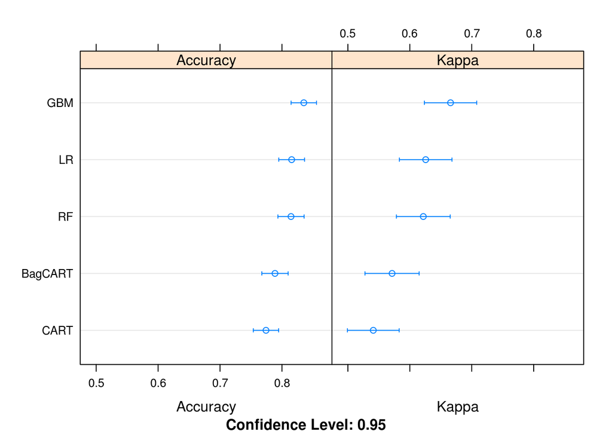

```r
dotplot(results)
```

```r
cat('The average accuracy from all models is:',
    mean(c(results$values$`LR~Accuracy`,results$values$`CART~Accuracy`,results$values$`BagCART~Accuracy`,results$values$`RF~Accuracy`,results$values$`GBM~Accuracy`)))
```

```
## The average accuracy from all models is: 0.8056621
```

## 5. Improve Accuracy or Results

After we achieve a short list of machine learning algorithms with good level of accuracy, we can leverage ways to improve the accuracy of the models.

### 5.a) Algorithm Tuning

Finally, we will tune the best-performing algorithms from each group further and see whether we can get more accuracy out of them.

```r
# Tuning algorithm #1 - Random Forest
email_notify(paste("Algorithm #1 tuning has begun!",date()))
```

```
## [1] "Java-Object{org.apache.commons.mail.SimpleEmail@6ea12c19}"
```

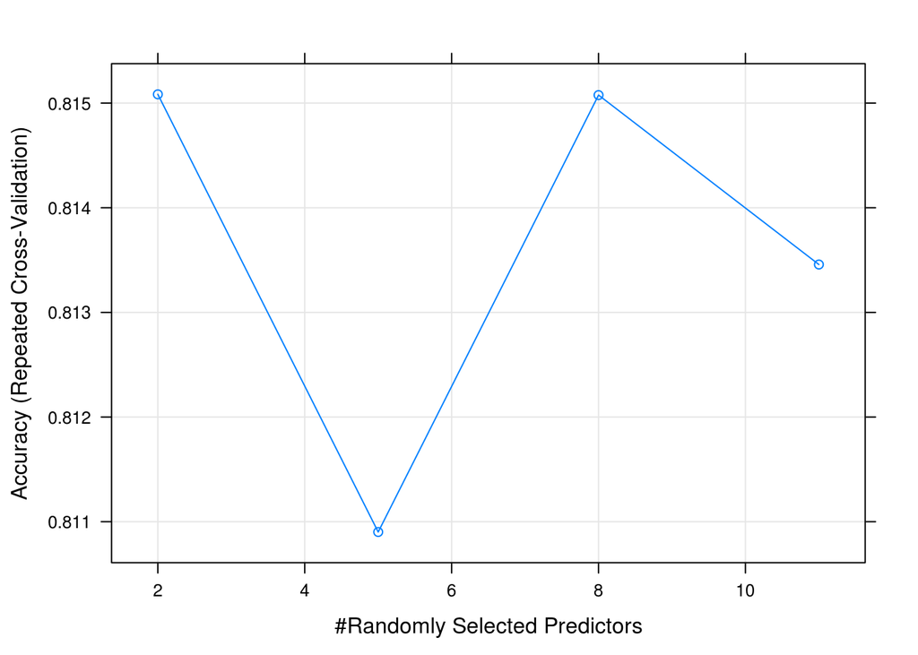

```r
startTimeModule <- proc.time()
set.seed(seedNum)
grid <- expand.grid(mtry=c(2,5,8,11))
fit.final1 <- train(targetVar~., data=xy_train, method="rf", metric=metricTarget, tuneGrid=grid, trControl=control)
plot(fit.final1)
```

```r
print(fit.final1)
```

```
## Random Forest
##
## 645 samples
##  11 predictor
##   2 classes: '0', '1'
##
## No pre-processing
## Resampling: Cross-Validated (10 fold, repeated 3 times)
## Summary of sample sizes: 580, 581, 581, 580, 580, 581, ...
## Resampling results across tuning parameters:
##
##   mtry  Accuracy   Kappa
##    2    0.8150838  0.6233031
##    5    0.8109014  0.6164001
##    8    0.8150766  0.6252079
##   11    0.8134575  0.6218365
##
## Accuracy was used to select the optimal model using the largest value.
## The final value used for the model was mtry = 2.
```

```r
proc.time()-startTimeModule
```

```
##    user  system elapsed
##  49.323   0.263  51.391
```

```r
email_notify(paste("Algorithm #1 tuning completed!",date()))
```

```
## [1] "Java-Object{org.apache.commons.mail.SimpleEmail@573f2bb1}"
```

```r
# Tuning algorithm #2 - Gradient Boosting
email_notify(paste("Algorithm #2 tuning has begun!",date()))
```

```
## [1] "Java-Object{org.apache.commons.mail.SimpleEmail@5dfcfece}"
```

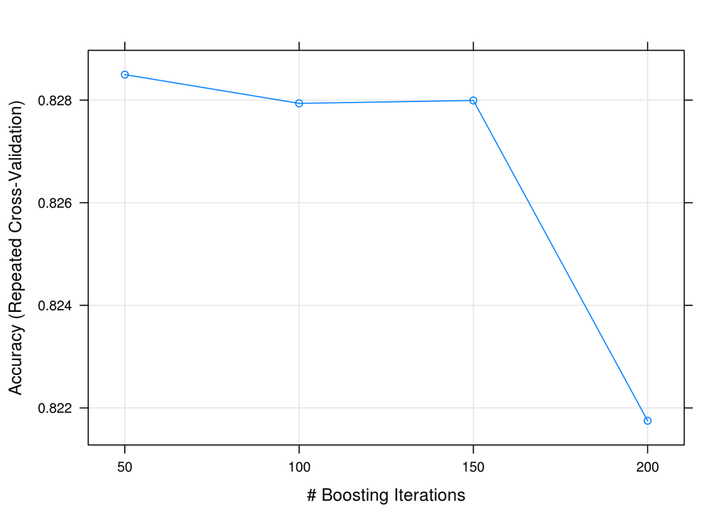

```r
startTimeModule <- proc.time()
set.seed(seedNum)
grid <- expand.grid(nrounds=c(50,100,150,200), max_depth=1, eta=0.3, gamma=0, colsample_bytree=0.8, min_child_weight=1, subsample=0.75)
fit.final2 <- train(targetVar~., data=xy_train, method="xgbTree", metric=metricTarget, tuneGrid=grid, trControl=control, verbose=F)
plot(fit.final2)
```

```r
print(fit.final2)
```

[output not shown]

```r
proc.time()-startTimeModule
```

```
##    user  system elapsed
##  10.629   0.141   8.782
```

```r
email_notify(paste("Algorithm #2 tuning completed!",date()))
```

```
## [1] "Java-Object{org.apache.commons.mail.SimpleEmail@5034c75a}"
```

### 5.d) Compare Algorithms After Tuning

```r
results <- resamples(list(RF=fit.final1, GBM=fit.final2))
summary(results)
```

```
##
## Call:
## summary.resamples(object = results)
##
## Models: RF, GBM
## Number of resamples: 30
##
## Accuracy
##          Min.   1st Qu.    Median      Mean   3rd Qu.      Max. NA's
## RF  0.6923077 0.7722356 0.8153846 0.8150838 0.8560697 0.9230769    0
## GBM 0.7384615 0.7859375 0.8307692 0.8284973 0.8593750 0.9384615    0
##
## Kappa
##          Min.   1st Qu.    Median      Mean   3rd Qu.      Max. NA's
## RF  0.3773946 0.5366064 0.6251760 0.6233031 0.7089810 0.8438251    0
## GBM 0.4654088 0.5661617 0.6587112 0.6522523 0.7185756 0.8754789    0
```

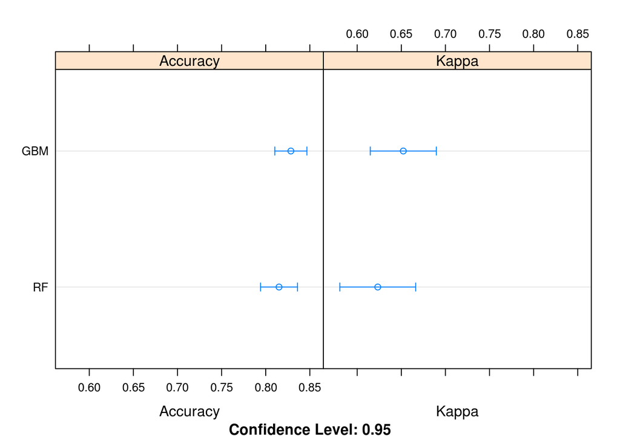

```r
dotplot(results)
```

## 6. Finalize Model and Present Results

Once we have narrow down to a model that we believe can make accurate predictions on unseen data, we are ready to finalize it. Finalizing a model may involve sub-tasks such as:

- Using an optimal model tuned to make predictions on unseen data.
- Creating a standalone model using the tuned parameters
- Saving an optimal model to file for later use.

```r
email_notify(paste("Model Validation and Final Model Creation has begun!",date()))
```

```
## [1] "Java-Object{org.apache.commons.mail.SimpleEmail@4f933fd1}"
```

### 6.a) Predictions on validation dataset

```r
predictions <- predict(fit.final2, newdata=xy_test)
confusionMatrix(predictions, y_test)
```

```
## Confusion Matrix and Statistics
##
##           Reference
## Prediction   0   1
##          0  84  22
##          1  39 130
##
##                Accuracy : 0.7782
##                  95% CI : (0.7244, 0.8259)
##     No Information Rate : 0.5527
##     P-Value [Acc > NIR] : 5.396e-15
##
##                   Kappa : 0.5454
##
##  Mcnemar's Test P-Value : 0.0405
##
##             Sensitivity : 0.6829
##             Specificity : 0.8553
##          Pos Pred Value : 0.7925
##          Neg Pred Value : 0.7692
##              Prevalence : 0.4473
##          Detection Rate : 0.3055
##    Detection Prevalence : 0.3855
##       Balanced Accuracy : 0.7691
##
##        'Positive' Class : 0
##
```

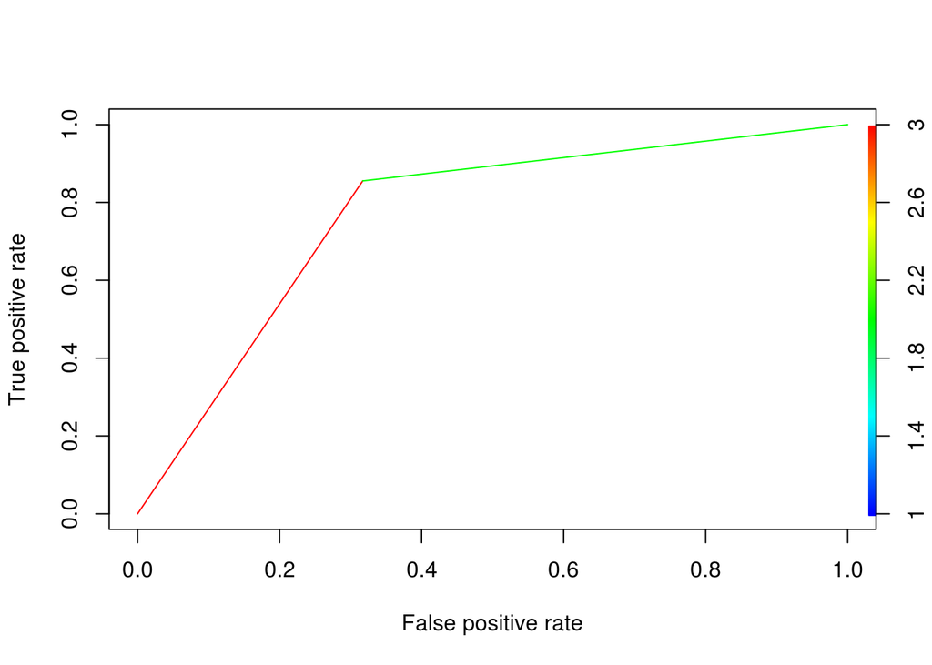

```r
pred <- prediction(as.numeric(predictions), as.numeric(y_test))
perf <- performance(pred, measure = "tpr", x.measure = "fpr")
plot(perf, colorize=TRUE)
```

```r
auc <- performance(pred, measure = "auc")
auc <- auc@y.values[[1]]
auc
```

```
## [1] 0.769095
```

### 6.b) Create standalone model on entire training dataset

```r
startTimeModule <- proc.time()
library(xgboost)
set.seed(seedNum)

# Combining the training and test datasets to form the original dataset that will be used for training the final model
xy_complete <- rbind(xy_train, xy_test)
y_final <- xy_complete$targetVar
xy_complete$targetVar <- NULL
x_final <- as.matrix(xy_complete)

# finalModel <- xgboost(data=x_final, label=y_final, nrounds=50, max_depth=1, eta=0.3, gamma=0, colsample_bytree=0.8, min_child_weight=1, subsample=0.5)
# print(finalModel)
proc.time()-startTimeModule
```

```
##    user  system elapsed
##   0.024   0.001   0.027
```

### 6.c) Save model for later use

```r
#saveRDS(finalModel, "./finalModel_BinaryClass.rds")
```

```r
email_notify(paste("Model Validation and Final Model Creation Completed!",date()))
```

```
## [1] "Java-Object{org.apache.commons.mail.SimpleEmail@1593948d}"
```

```r
proc.time()-startTimeScript
```

```
##    user  system elapsed
## 398.782   5.466 382.449
```